# Linear Model Pro SX and MX

# Setup

Let’s connect to the database and get the gate drop times.

```r
db_name <- 'gate_drop_5653b.db'
db_path <- here('_data',db_name)
query_path <-  here('notebooks', 'R_Notebooks','main_query.sql')
convenience_routines <- here('notebooks', 'R_Notebooks', 'convenience_routines.R')
url_db<- paste0('https://storage.googleapis.com/gate-drop-storage.simplifyingcomplexspaces.com/', db_name)
ref_md5 <- 'f8702809c5f5ade41cbb352accd5653b'

source(convenience_routines, local = knitr::knit_global())

# Check if the local db is present; if not,  download it
if (!file.exists(db_path)){
    getRemoteDBfile(url_db, db_path)
}
# Check the hash of the db file; if matches what's specified in the notebook, proceed; if not, download from remote
if (tools::md5sum(db_path) != ref_md5){
    getRemoteDBfile(url_db, db_path)
}

src_db <- DBI::dbConnect(RSQLite::SQLite(),db_path)
main_query <- paste(readLines(query_path), collapse='\n')
main_dat <- DBI::dbGetQuery(conn = src_db, statement = main_query)
DBI::dbDisconnect(conn = src_db)
```

This analysis includes 146 separate observations from 19 Pro SX rounds.

# Histograms

Now, let’s do some fundamental analysis to get the margin of error for all gate drop times.

```r
t_data <- main_dat |>  tibble::as_tibble()

# Drop extra columns we don't need to keep
t_data <- t_data |> dplyr::select (-one_of(c("row_id","Date", "Venue", "Round","Comments")))

# make the logistic variables numeric and replace NA with 0
t_data <- t_data |> dplyr::mutate_if(is.logical, as.numeric)
t_data <- t_data |> dplyr::mutate_all(funs(replace_na(.,0)))

t_moe_factor <- qt(0.025, nrow(t_data), lower.tail = FALSE)
t_moe <- t_moe_factor * sd(t_data$`sec to drop`) / sqrt(nrow(t_data))
```

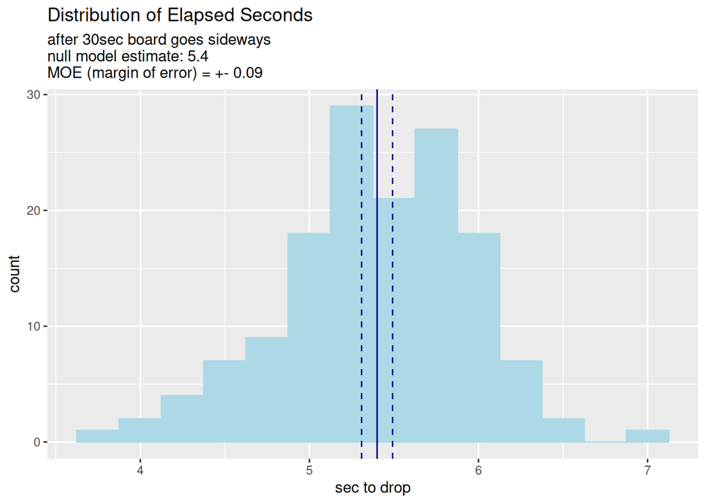

```r
null_model <- mean(t_data$`sec to drop`)
lower_ci <- null_model - t_moe
upper_ci <- null_model + t_moe

gp1 <- ggplot(data = t_data, aes(x= `sec to drop`))+geom_histogram(binwidth = 0.25,color="light blue", fill="light blue") +
    geom_vline(aes(xintercept = null_model), color = "dark blue")+
    geom_vline(aes(xintercept = lower_ci), color = "dark blue", linetype = "dashed")+
    geom_vline(aes(xintercept = upper_ci), color = "dark blue", linetype = "dashed")+
    labs(title = "Distribution of Elapsed Seconds",
         subtitle = paste("after 30sec board goes sideways",
                          "\nnull model estimate:", round(mean(t_data$`sec to drop`), 2),
                          "\nMOE (margin of error) = +-", round(t_moe, 2))) + scale_x_continuous()
gp1
```

# MLR Model

Let’s build a linear model to predict the gate drop times

```r
t_data_src_cols <- colnames(t_data)
t_data_src_cols <- t_data_src_cols[!t_data_src_cols == 'sec to drop'] #stage this for later when we make predictions

t_model <- lm(`sec to drop` ~ . , data = t_data)
print(summary(t_model))
```

```
##
## Call:
## lm(formula = `sec to drop` ~ ., data = t_data)
##
## Residuals:
##     Min      1Q  Median      3Q     Max
## -1.4626 -0.3686  0.0133  0.4342  1.4803
##
## Coefficients: (2 not defined because of singularities)
##               Estimate Std. Error t value Pr(>|t|)
## (Intercept)    6.09014    0.34027  17.898   <2e-16 ***
## `SX Futures`  -0.14884    0.31984  -0.465   0.6424
## `250 SX East` -0.16583    0.22767  -0.728   0.4676
## `250 SX West`  0.02003    0.22675   0.088   0.9297
## `450 SX`      -0.11809    0.23701  -0.498   0.6191
## `450 MX`            NA         NA      NA       NA
## `250 MX`            NA         NA      NA       NA
## Heat          -0.59941    0.29834  -2.009   0.0465 *
## LCQ           -0.73954    0.30703  -2.409   0.0173 *
## Final         -0.54155    0.29856  -1.814   0.0719 .
## ---
## Signif. codes:  0 '***' 0.001 '**' 0.01 '*' 0.05 '.' 0.1 ' ' 1
##
## Residual standard error: 0.556 on 138 degrees of freedom
## Multiple R-squared:  0.06532,    Adjusted R-squared:  0.01791
## F-statistic: 1.378 on 7 and 138 DF,  p-value: 0.2194
```

```r
t_beta <- round(coefficients(t_model),2)
print(t_beta)
```

```
##   (Intercept)  `SX Futures` `250 SX East` `250 SX West`      `450 SX`
##          6.09         -0.15         -0.17          0.02         -0.12
##      `450 MX`      `250 MX`          Heat           LCQ         Final
##            NA            NA         -0.60         -0.74         -0.54
```

$$\vspace{0.5cm}$$
Here’s our fitted model:

$\hat{y}$ = 6.09 + -0.15$x_1$ + -0.17$x_2$ + 0.02$x_3$ + -0.12$x_4$ + NA$x_5$ + NA$x_6$ + -0.6$x_7$ + -0.74$x_8$ + -0.54 $x_9$

So, translating the coefficients, we can determine the following. Looking at the y_intercept, we can see that, without any other information, we would predict the gate to drop in 6.09 seconds. For all of our features $\beta_1$ - $\beta_{9}$, they are indicator random variables (aka characteristic random variables) where we have encoded the race classes `SX Futures’, ‘250 SX East’, ‘250 SX West’, ‘450 SX’, ‘450 MX’, and ‘250 MX.’ Further we have applied the convention to the ‘Heat’, ‘LCQ’, and ‘Final’ variables. In summary:

Beta Coefficients Discussion

[output not shown]

$$\newline
\vspace{0.25cm}$$

## Model Checking

### Normalcy

Let’s do some basic model checking. First, let’s check to see if the data follows the normal distribution. We can do this by evaluating the ranked residuals against the theoretical ideal corresponding point in the normal cumulative distribution function. If the ranked residuals generally follow the theoretical line, then we can declare the data follows the normal distribution.

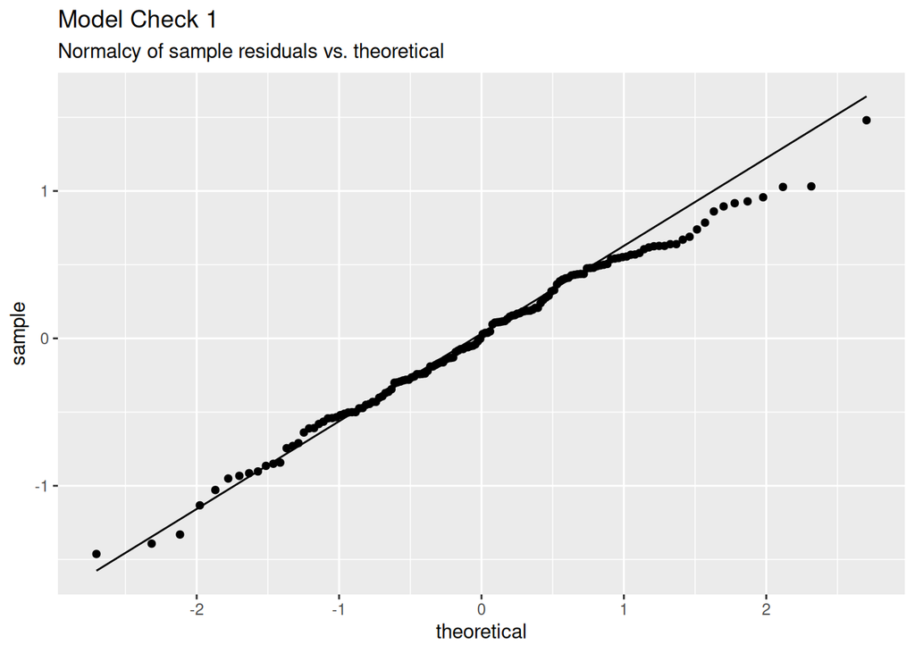

```r
unscaled_residual <- tibble(t_model$residuals)

t_data <- t_data |>bind_cols(unscaled_residual)
t_length <- length(t_data)
colnames(t_data)[t_length] <- 'unscaled_residual'

t_qq_plot <- ggplot(data = t_data, aes(sample = unscaled_residual)) +stat_qq() + stat_qq_line() +
    labs(title =  "Model Check 1", subtitle = "Normalcy of sample residuals vs. theoretical", y = "sample", x = "theoretical")
t_qq_plot
```

### Residuals

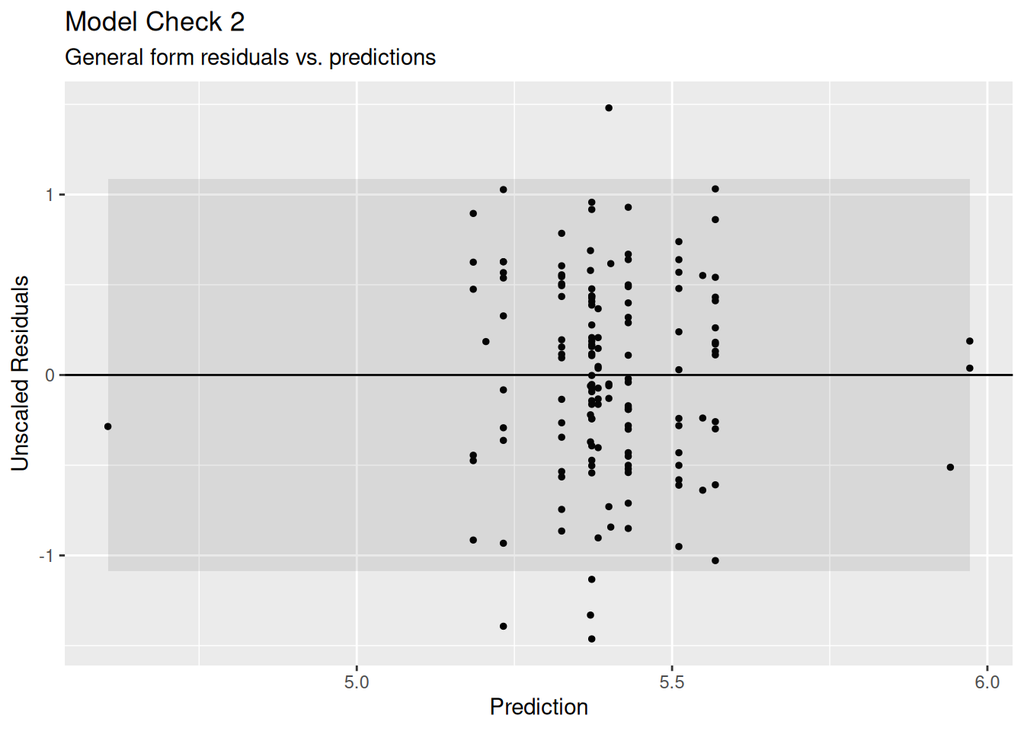

```r
t_predicted_response <- tibble(t_model$fitted.values)
highbound <- 2 * sd(t_data$unscaled_residual)
lowbound <- -2 * sd(t_data$unscaled_residual)

t_data <- t_data |>bind_cols(t_predicted_response)
t_length <- length(t_data)
colnames(t_data)[t_length]  <- 't_prediction'
q <- ggplot(data = t_data, aes(y = `unscaled_residual`, x = `t_prediction` )) + geom_point(size=1) +
    labs(title =  "Model Check 2", subtitle = "General form residuals vs. predictions", y = "Unscaled Residuals", x = "Prediction") + geom_hline(yintercept = 0) +
    geom_ribbon(aes(ymin = lowbound, ymax = highbound), alpha = 0.1)
q
```

Above, the shaded region indicates $\pm2\sigma$ of the unscaled residuals against each of the predictions. Given that most of the predictions fit within the shaded area, we can say this model passes this check as well.

# Predictions

Let’s make some predictions for the 250 and 450 main events!

```r
pred_250_main_SX_east <- c(0,1,0,0,0,0,0,0,1)
pred_250_main_SX_west <- c(0,0,1,0,0,0,0,0,1)
pred_450_main_SX <- c(0,0,0,1,0,0,0,0,1)
p_dat <- tibble()
p_dat <- rbind(p_dat, pred_250_main_SX_east, pred_250_main_SX_west, pred_450_main_SX)
names(p_dat) <- t_data_src_cols

a_prediction <- predict(t_model, p_dat, interval = 'confidence')
```

Main Event Predictions

| Class | Estimate | Lower Bound | Upper Bound |
| --- | --- | --- | --- |
| 250 SX East | 5.38 | 5.16 | 5.61 |
| 250 SX West | 5.57 | 5.35 | 5.78 |
| 450 SX | 5.43 | 5.25 | 5.61 |